# Assignment4

## Run k-means algorithm (k=4)

```r
#run the k-means algorithm to cluster the companies (k=4) in order to evaluate the clustering quality
k4<-kmeans(mydata_scale, centers=4, nstart=25) # test run with k=4, and 25 starts (re-run).
k4
```

```
## K-means clustering with 4 clusters of sizes 3, 8, 6, 4
##
## Cluster means:
##    Market_Cap       Beta   PE_Ratio        ROE        ROA Asset_Turnover
## 1 -0.52462814  0.4451409  1.8498439 -1.0404550 -1.1865838   1.480297e-16
## 2 -0.03142211 -0.4360989 -0.3172485  0.1950459  0.4083915   1.729746e-01
## 3 -0.82617719  0.4775991 -0.3696184 -0.5631589 -0.8514589  -9.994088e-01
## 4  1.69558112 -0.1780563 -0.1984582  1.2349879  1.3503431   1.153164e+00
##     Leverage Rev_Growth Net_Profit_Margin
## 1 -0.3443544 -0.5769454        -1.6095439
## 2 -0.2744931 -0.7041516         0.5569544
## 3  0.8502201  0.9158889        -0.3319956
## 4 -0.4680782  0.4671788         0.5912425
##
## Clustering vector:
##  ABT  AGN  AHM  AZN  AVE  BAY  BMY CHTT  ELN  LLY  GSK  IVX  JNJ  MRX  MRK  NVS
##    2    1    2    2    3    1    2    3    3    2    4    3    4    3    4    2
##  PFE  PHA  SGP  WPI  WYE
##    4    1    2    3    2
##
## Within cluster sum of squares by cluster:
## [1] 14.938904 21.879320 32.143356  9.284424
##  (between_SS / total_SS =  56.5 %)
##
## Available components:
##
## [1] "cluster"      "centers"      "totss"        "withinss"     "tot.withinss"
## [6] "betweenss"    "size"         "iter"         "ifault"
```

```r
#[Section 1.2.5]
cluster4<-data.frame(k4$cluster)
View(cluster4)
glance(k4)
```

| totss | tot.withinss | betweenss | iter |
| --- | --- | --- | --- |
| 180 | 78.246 | 101.754 | 2 |

```r
#[Section 1.2.6]
dunn_k4<- dunn(clusters = k4$cluster, Data = mydata_scale) #A higher value is considerably superior.
dunn_k4
```

```
## [1] 0.3355922
```

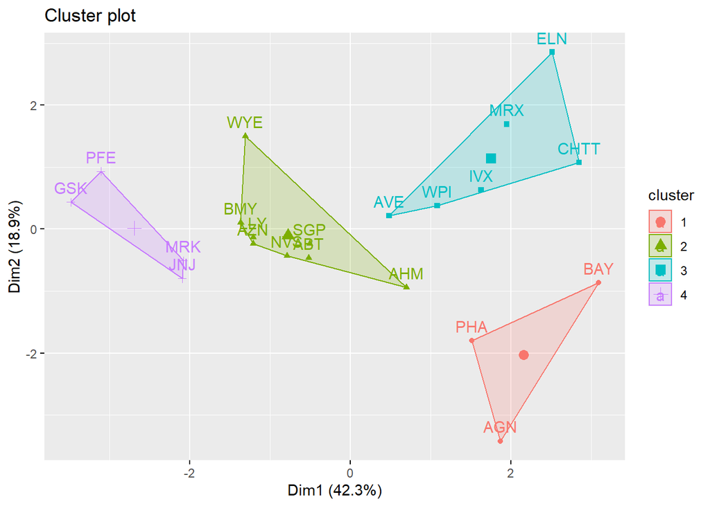

```r
fviz_cluster(k4,data=mydata_scale) #Visualize the cluster
```

```r
#[Section 1.3.1], Best variables that separating the clusters: Contributing variables for cluster spread
k4$spread<-as.data.frame(t(k4$centers))
k4$spread$max<-do.call(pmax, k4$spread[1:4])# find the highest value within the row (each financial performance feature) and save the value to "max"
k4$spread$min<-do.call(pmin, k4$spread[1:4])# find the lowest value within the row (each financial performance feature) and save the value to "min"
k4$spread$gap<-k4$spread$max-k4$spread$min # calculate the difference between max and min
k4$spread
```

|  | 1 | 2 | 3 | 4 | max | min | gap |
| --- | --- | --- | --- | --- | --- | --- | --- |
| Market_Cap | -5.246281e-01 | -0.03142211 | -0.8261772 | 1.6955811 | 1.6955811 | -0.8261772 | 2.521758 |
| Beta | 4.451409e-01 | -0.43609894 | 0.4775991 | -0.1780563 | 0.4775991 | -0.4360989 | 0.913698 |
| PE_Ratio | 1.849844e+00 | -0.31724852 | -0.3696184 | -0.1984582 | 1.8498439 | -0.3696184 | 2.219462 |
| ROE | -1.040455e+00 | 0.19504586 | -0.5631589 | 1.2349879 | 1.2349879 | -1.0404550 | 2.275443 |
| ROA | -1.186584e+00 | 0.40839154 | -0.8514589 | 1.3503431 | 1.3503431 | -1.1865838 | 2.536927 |
| Asset_Turnover | 1.480297e-16 | 0.17297460 | -0.9994088 | 1.1531640 | 1.1531640 | -0.9994088 | 2.152573 |
| Leverage | -3.443544e-01 | -0.27449312 | 0.8502201 | -0.4680782 | 0.8502201 | -0.4680782 | 1.318298 |
| Rev_Growth | -5.769454e-01 | -0.70415156 | 0.9158889 | 0.4671788 | 0.9158889 | -0.7041516 | 1.620040 |
| Net_Profit_Margin | -1.609544e+00 | 0.55695445 | -0.3319956 | 0.5912425 | 0.5912425 | -1.6095439 | 2.200786 |

## Run k-means algorithm (k=5)

```r
#run the k-means algorithm to cluster the companies (k=5) in order to evaluate the clustering quality
k5<-kmeans(mydata_scale, centers=5, nstart=25) # test run with k=5, and 25 starts (re-run).
k5
```

```
## K-means clustering with 5 clusters of sizes 2, 8, 4, 4, 3
##
## Cluster means:
##    Market_Cap       Beta    PE_Ratio        ROE        ROA Asset_Turnover
## 1 -0.43925134 -0.4701800  2.70002464 -0.8349525 -0.9234951      0.2306328
## 2 -0.03142211 -0.4360989 -0.31724852  0.1950459  0.4083915      0.1729746
## 3 -0.76022489  0.2796041 -0.47742380 -0.7438022 -0.8107428     -1.2684804
## 4  1.69558112 -0.1780563 -0.19845823  1.2349879  1.3503431      1.1531640
## 5 -0.87051511  1.3409869 -0.05284434 -0.6184015 -1.1928478     -0.4612656
##      Leverage Rev_Growth Net_Profit_Margin
## 1 -0.14170336 -0.1168459      -1.416514761
## 2 -0.27449312 -0.7041516       0.556954446
## 3  0.06308085  1.5180158      -0.006893899
## 4 -0.46807818  0.4671788       0.591242521
## 5  1.36644699 -0.6912914      -1.320000179
##
## Clustering vector:
##  ABT  AGN  AHM  AZN  AVE  BAY  BMY CHTT  ELN  LLY  GSK  IVX  JNJ  MRX  MRK  NVS
##    2    1    2    2    3    5    2    5    3    2    4    5    4    3    4    2
##  PFE  PHA  SGP  WPI  WYE
##    4    1    2    3    2
##
## Within cluster sum of squares by cluster:
## [1]  2.803505 21.879320 12.791257  9.284424 15.595925
##  (between_SS / total_SS =  65.4 %)
##
## Available components:
##
## [1] "cluster"      "centers"      "totss"        "withinss"     "tot.withinss"
## [6] "betweenss"    "size"         "iter"         "ifault"
```

```r
#[Section 1.2.5]
cluster5<-data.frame(k5$cluster)
View(cluster5)
glance(k5)
```

| totss | tot.withinss | betweenss | iter |
| --- | --- | --- | --- |
| 180 | 62.35443 | 117.6456 | 3 |

```r
#[Section 1.2.6]
dunn_k5<- dunn(clusters = k5$cluster, Data = mydata_scale) #A higher value is considerably superior.
dunn_k5
```

```
## [1] 0.3741429
```

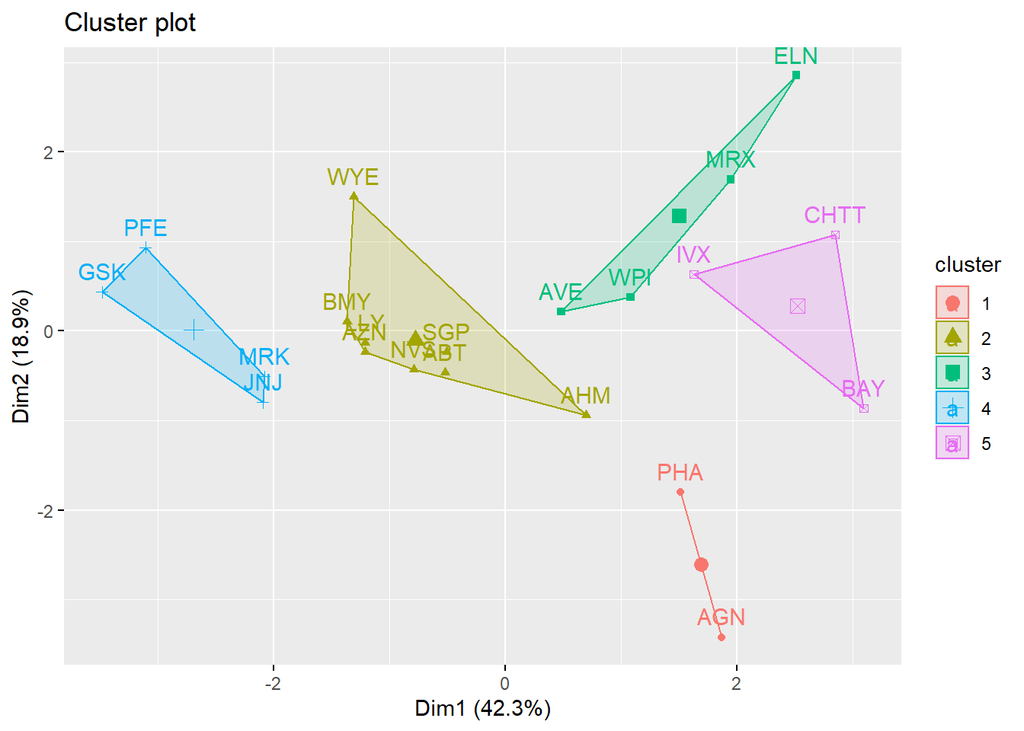

```r
fviz_cluster(k5,data=mydata_scale) #Visualize the cluster
```

```r
#[Section 1.3.2], Best variables that separating the clusters: Contributing variables for cluster spread
k5$spread<-as.data.frame(t(k5$centers))
k5$spread$max<-do.call(pmax, k5$spread[1:4]) # find the highest value within the row (each financial performance feature) and save the value to "max"
k5$spread$min<-do.call(pmin, k5$spread[1:4])# find the lowest value within the row (each financial performance feature) and save the value to "min"
k5$spread$gap<-k5$spread$max-k5$spread$min# calculate the difference between max and min
k5$spread
```

|  | 1 | 2 | 3 | 4 | 5 | max | min | gap |
| --- | --- | --- | --- | --- | --- | --- | --- | --- |
| Market_Cap | -0.4392513 | -0.03142211 | -0.760224892 | 1.6955811 | -0.87051511 | 1.69558112 | -0.7602249 | 2.4558060 |
| Beta | -0.4701800 | -0.43609894 | 0.279604106 | -0.1780563 | 1.34098686 | 0.27960411 | -0.4701800 | 0.7497841 |
| PE_Ratio | 2.7000246 | -0.31724852 | -0.477423799 | -0.1984582 | -0.05284434 | 2.70002464 | -0.4774238 | 3.1774484 |
| ROE | -0.8349525 | 0.19504586 | -0.743802224 | 1.2349879 | -0.61840151 | 1.23498791 | -0.8349525 | 2.0699404 |
| ROA | -0.9234951 | 0.40839154 | -0.810742783 | 1.3503431 | -1.19284783 | 1.35034311 | -0.9234951 | 2.2738382 |
| Asset_Turnover | 0.2306328 | 0.17297460 | -1.268480411 | 1.1531640 | -0.46126560 | 1.15316401 | -1.2684804 | 2.4216444 |
| Leverage | -0.1417034 | -0.27449312 | 0.063080849 | -0.4680782 | 1.36644699 | 0.06308085 | -0.4680782 | 0.5311590 |
| Rev_Growth | -0.1168459 | -0.70415156 | 1.518015830 | 0.4671788 | -0.69129140 | 1.51801583 | -0.7041516 | 2.2221674 |
| Net_Profit_Margin | -1.4165148 | 0.55695445 | -0.006893899 | 0.5912425 | -1.32000018 | 0.59124252 | -1.4165148 | 2.0077573 |

## Run k-means algorithm (k=6)

```r
#run the k-means algorithm to cluster the companies (k=6) in order to evaluate the clustering quality
k6<-kmeans(mydata_scale, centers=6, nstart=25) # test run with k=6, and 25 starts (re-run).
k6
```

```
## K-means clustering with 6 clusters of sizes 8, 1, 2, 4, 1, 5
##
## Cluster means:
##    Market_Cap       Beta    PE_Ratio        ROE        ROA Asset_Turnover
## 1 -0.03142211 -0.4360989 -0.31724852  0.1950459  0.4083915      0.1729746
## 2 -0.97676686  1.2630872  0.03299122 -0.1123792 -1.1677918     -0.4612656
## 3 -0.43925134 -0.4701800  2.70002464 -0.8349525 -0.9234951      0.2306328
## 4  1.69558112 -0.1780563 -0.19845823  1.2349879  1.3503431      1.1531640
## 5 -0.69538175  2.2757827  0.14948233 -1.4514600 -1.7127612     -0.4612656
## 6 -0.79605926  0.3205014 -0.45014035 -0.6533148 -0.7881923     -1.1070374
##     Leverage Rev_Growth Net_Profit_Margin
## 1 -0.2744931 -0.7041516         0.5569544
## 2  3.7427970 -0.6327607        -1.2488842
## 3 -0.1417034 -0.1168459        -1.4165148
## 4 -0.4680782  0.4671788         0.5912425
## 5 -0.7496565 -1.4971443        -1.9956023
## 6  0.2717048  1.2256188        -0.1486179
##
## Clustering vector:
##  ABT  AGN  AHM  AZN  AVE  BAY  BMY CHTT  ELN  LLY  GSK  IVX  JNJ  MRX  MRK  NVS
##    1    3    1    1    6    5    1    2    6    1    4    6    4    6    4    1
##  PFE  PHA  SGP  WPI  WYE
##    4    3    1    6    1
##
## Within cluster sum of squares by cluster:
## [1] 21.879320  0.000000  2.803505  9.284424  0.000000 16.542597
##  (between_SS / total_SS =  71.9 %)
##
## Available components:
##
## [1] "cluster"      "centers"      "totss"        "withinss"     "tot.withinss"
## [6] "betweenss"    "size"         "iter"         "ifault"
```

```r
cluster6<-data.frame(k6$cluster)
View(cluster6)
glance(k6)
```

| totss | tot.withinss | betweenss | iter |
| --- | --- | --- | --- |
| 180 | 50.50985 | 129.4902 | 2 |

```r
dunn_k6<- dunn(clusters = k6$cluster, Data = mydata_scale)
dunn_k6
```

```
## [1] 0.4442093
```

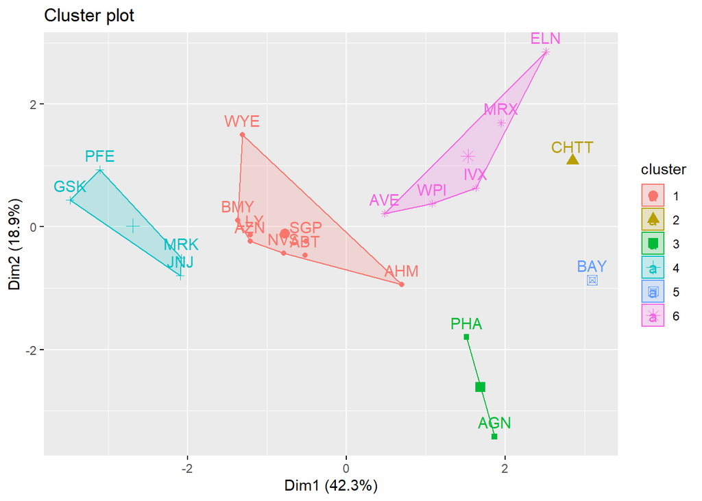

```r
#[Section 1.2.4]
fviz_cluster(k6,data=mydata_scale) #Visualize the cluster
```

```r
#Best variables that separating the clusters: Contributing variables for cluster spread
k6$spread<-as.data.frame(t(k6$centers))
k6$spread$max<-do.call(pmax, k6$spread[1:4]) # find the highest value within the row (each financial performance feature) and save the value to "max"
k6$spread$min<-do.call(pmin, k6$spread[1:4])# find the lowest value within the row (each financial performance feature) and save the value to "min"
k6$spread$gap<-k5$spread$max-k5$spread$min# calculate the difference between max and min
k6$spread
```

|  | 1 | 2 | 3 | 4 | 5 | 6 | max | min | gap |
| --- | --- | --- | --- | --- | --- | --- | --- | --- | --- |
| Market_Cap | -0.03142211 | -0.97676686 | -0.4392513 | 1.6955811 | -0.6953818 | -0.7960593 | 1.6955811 | -0.9767669 | 2.4558060 |
| Beta | -0.43609894 | 1.26308721 | -0.4701800 | -0.1780563 | 2.2757827 | 0.3205014 | 1.2630872 | -0.4701800 | 0.7497841 |
| PE_Ratio | -0.31724852 | 0.03299122 | 2.7000246 | -0.1984582 | 0.1494823 | -0.4501404 | 2.7000246 | -0.3172485 | 3.1774484 |
| ROE | 0.19504586 | -0.11237924 | -0.8349525 | 1.2349879 | -1.4514600 | -0.6533148 | 1.2349879 | -0.8349525 | 2.0699404 |
| ROA | 0.40839154 | -1.16779176 | -0.9234951 | 1.3503431 | -1.7127612 | -0.7881923 | 1.3503431 | -1.1677918 | 2.2738382 |
| Asset_Turnover | 0.17297460 | -0.46126560 | 0.2306328 | 1.1531640 | -0.4612656 | -1.1070374 | 1.1531640 | -0.4612656 | 2.4216444 |
| Leverage | -0.27449312 | 3.74279705 | -0.1417034 | -0.4680782 | -0.7496565 | 0.2717048 | 3.7427970 | -0.4680782 | 0.5311590 |
| Rev_Growth | -0.70415156 | -0.63276071 | -0.1168459 | 0.4671788 | -1.4971443 | 1.2256188 | 0.4671788 | -0.7041516 | 2.2221674 |
| Net_Profit_Margin | 0.55695445 | -1.24888417 | -1.4165148 | 0.5912425 | -1.9956023 | -0.1486179 | 0.5912425 | -1.4165148 | 2.0077573 |

# 2. Profile of each cluster

**Interpret the clusters with respect to the numerical variables used in forming the clusters.**

**Solution:**

```r
k5$cluster
```

```
##  ABT  AGN  AHM  AZN  AVE  BAY  BMY CHTT  ELN  LLY  GSK  IVX  JNJ  MRX  MRK  NVS
##    2    1    2    2    3    5    2    5    3    2    4    5    4    3    4    2
##  PFE  PHA  SGP  WPI  WYE
##    4    1    2    3    2
```

##Cluster Size

```r
#[Section 2.1]
k5$size
```

```
## [1] 2 8 4 4 3
```

```r
table(k5$cluster)
```

```
##
## 1 2 3 4 5
## 2 8 4 4 3
```

```r
k5$centers
```

```
##    Market_Cap       Beta    PE_Ratio        ROE        ROA Asset_Turnover
## 1 -0.43925134 -0.4701800  2.70002464 -0.8349525 -0.9234951      0.2306328
## 2 -0.03142211 -0.4360989 -0.31724852  0.1950459  0.4083915      0.1729746
## 3 -0.76022489  0.2796041 -0.47742380 -0.7438022 -0.8107428     -1.2684804
## 4  1.69558112 -0.1780563 -0.19845823  1.2349879  1.3503431      1.1531640
## 5 -0.87051511  1.3409869 -0.05284434 -0.6184015 -1.1928478     -0.4612656
##      Leverage Rev_Growth Net_Profit_Margin
## 1 -0.14170336 -0.1168459      -1.416514761
## 2 -0.27449312 -0.7041516       0.556954446
## 3  0.06308085  1.5180158      -0.006893899
## 4 -0.46807818  0.4671788       0.591242521
## 5  1.36644699 -0.6912914      -1.320000179
```

## Within-cluster sum of Squares

```r
#[Section 2.2]
k5$withinss # Vector of within-cluster sum of squares, one component per cluster.
```

```
## [1]  2.803505 21.879320 12.791257  9.284424 15.595925
```

```r
dist(k5$centers) #distance between the centers
```

```
##          1        2        3        4
## 2 4.045579
## 3 4.210877 3.299161
## 4 5.275301 2.720924 4.744753
## 5 3.775790 3.711570 3.230532 5.457397
```

## Plotting profile (centroid) of clusters

```r
#[Section 2.3], plotting profile plot based on the scaled value (k=5)
cluster5dimension<-data.frame(k5$centers)
print(cluster5dimension)#Dimension information (scaled data) (mean value of each attribute)
```

```
##    Market_Cap       Beta    PE_Ratio        ROE        ROA Asset_Turnover
## 1 -0.43925134 -0.4701800  2.70002464 -0.8349525 -0.9234951      0.2306328
## 2 -0.03142211 -0.4360989 -0.31724852  0.1950459  0.4083915      0.1729746
## 3 -0.76022489  0.2796041 -0.47742380 -0.7438022 -0.8107428     -1.2684804
## 4  1.69558112 -0.1780563 -0.19845823  1.2349879  1.3503431      1.1531640
## 5 -0.87051511  1.3409869 -0.05284434 -0.6184015 -1.1928478     -0.4612656
##      Leverage Rev_Growth Net_Profit_Margin
## 1 -0.14170336 -0.1168459      -1.416514761
## 2 -0.27449312 -0.7041516       0.556954446
## 3  0.06308085  1.5180158      -0.006893899
## 4 -0.46807818  0.4671788       0.591242521
## 5  1.36644699 -0.6912914      -1.320000179
```

```r
cluster5dimensions<-as.data.frame(t(cluster5dimension)) # Transposed the rows and columns
cluster5dimensions$k5measures <- rownames(cluster5dimensions)
cluster5dimensions
```

|  | 1 | 2 | 3 | 4 | 5 | k5measures |
| --- | --- | --- | --- | --- | --- | --- |
| Market_Cap | -0.4392513 | -0.03142211 | -0.760224892 | 1.6955811 | -0.87051511 | Market_Cap |
| Beta | -0.4701800 | -0.43609894 | 0.279604106 | -0.1780563 | 1.34098686 | Beta |
| PE_Ratio | 2.7000246 | -0.31724852 | -0.477423799 | -0.1984582 | -0.05284434 | PE_Ratio |
| ROE | -0.8349525 | 0.19504586 | -0.743802224 | 1.2349879 | -0.61840151 | ROE |
| ROA | -0.9234951 | 0.40839154 | -0.810742783 | 1.3503431 | -1.19284783 | ROA |
| Asset_Turnover | 0.2306328 | 0.17297460 | -1.268480411 | 1.1531640 | -0.46126560 | Asset_Turnover |
| Leverage | -0.1417034 | -0.27449312 | 0.063080849 | -0.4680782 | 1.36644699 | Leverage |
| Rev_Growth | -0.1168459 | -0.70415156 | 1.518015830 | 0.4671788 | -0.69129140 | Rev_Growth |
| Net_Profit_Margin | -1.4165148 | 0.55695445 | -0.006893899 | 0.5912425 | -1.32000018 | Net_Profit_Margin |

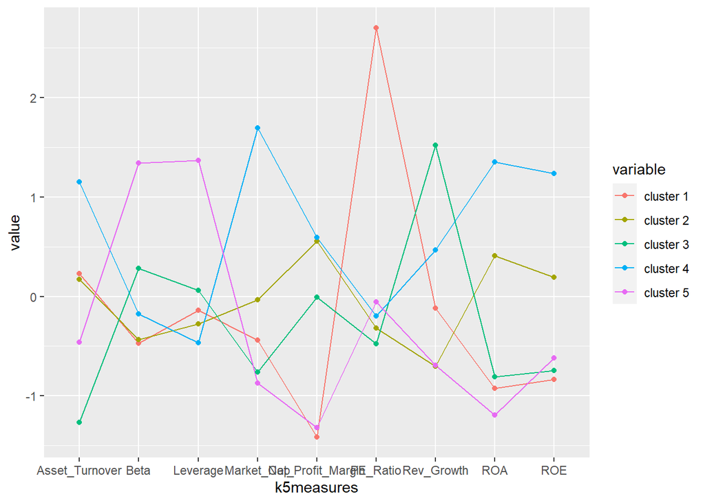

```r
colnames(cluster5dimensions) <- c("cluster 1","cluster 2","cluster 3","cluster 4","cluster 5", "k5measures") # change the column names
cluster5dimensions <- melt(cluster5dimensions, id.vars=c("k5measures"))
ggplot(cluster5dimensions, aes(x=k5measures, y=value, color=variable, group=variable)) + geom_line() + geom_point()
```

```r
#ground work to see the characteristics of each cluster based on the raw values
mydata_scale_cluster5<-cbind(mydata_scale, cluster5) # attach the cluster number generated based on k=5 to the scaled data set.
mydata_cluster5<-cbind(mydata, cluster5) # attach the cluster number generated based on k=5 to the working data set (original variables 1-9).
Pharmaceuticals_cluster5<-cbind(Pharmaceuticals, cluster5) # attach the cluster number generated based on k=5 to the original data set.
View(mydata_scale_cluster5)
View(mydata_cluster5)
View(Pharmaceuticals_cluster5)
```

## Characteristics of each cluster

```r
#Cluster 1 characteristics based on the raw values
cluster5_1<-filter(mydata_cluster5,k5.cluster==1)
print(cluster5_1)
```

```
##     Market_Cap Beta PE_Ratio  ROE ROA Asset_Turnover Leverage Rev_Growth
## AGN       7.58 0.41     82.5 12.9 5.5            0.9     0.60       9.16
## PHA      56.24 0.40     56.5 13.5 5.7            0.6     0.35      15.00
##     Net_Profit_Margin k5.cluster
## AGN               5.5          1
## PHA               7.3          1
```

```r
#Cluster 2 characteristics based on the raw values
cluster5_2<-filter(mydata_cluster5,k5.cluster==2)
print(cluster5_2)
```

```
##     Market_Cap Beta PE_Ratio  ROE  ROA Asset_Turnover Leverage Rev_Growth
## ABT      68.44 0.32     24.7 26.4 11.8            0.7     0.42       7.54
## AHM       6.30 0.46     20.7 14.9  7.8            0.9     0.27       7.05
## AZN      67.63 0.52     21.5 27.4 15.4            0.9     0.00      15.00
## BMY      51.33 0.50     13.9 34.8 15.1            0.9     0.57       2.70
## LLY      73.84 0.18     27.9 31.0 13.5            0.6     0.53       6.21
## NVS      96.65 0.19     21.6 17.9 11.2            0.5     0.06      -2.69
## SGP      34.10 0.51     18.9 22.6 13.3            0.8     0.00       8.56
## WYE      48.19 0.63     13.1 54.9 13.4            0.6     1.12       0.36
##     Net_Profit_Margin k5.cluster
## ABT              16.1          2
## AHM              11.2          2
## AZN              18.0          2
## BMY              20.6          2
## LLY              23.4          2
## NVS              22.4          2
## SGP              17.6          2
## WYE              25.5          2
```

```r
#Cluster 3 characteristics based on the raw values
cluster5_3<-filter(mydata_cluster5,k5.cluster==3)
print(cluster5_3)
```

```
##     Market_Cap Beta PE_Ratio  ROE ROA Asset_Turnover Leverage Rev_Growth
## AVE      47.16 0.32     20.1 21.8 7.5            0.6     0.34      26.81
## ELN       0.78 1.08      3.6 15.1 5.1            0.3     1.07      34.21
## MRX       1.20 0.75     28.6 11.2 5.4            0.3     0.93      30.37
## WPI       3.26 0.24     18.4 10.2 6.8            0.5     0.20      29.18
##     Net_Profit_Margin k5.cluster
## AVE              12.9          3
## ELN              13.3          3
## MRX              21.3          3
## WPI              15.1          3
```

```r
#Cluster 4 characteristics based on the raw values
cluster5_4<-filter(mydata_cluster5,k5.cluster==4)
print(cluster5_4)
```

```
##     Market_Cap Beta PE_Ratio  ROE  ROA Asset_Turnover Leverage Rev_Growth
## GSK     122.11 0.35     18.0 62.9 20.3            1.0     0.34      21.87
## JNJ     173.93 0.46     28.4 28.6 16.3            0.9     0.10       9.37
## MRK     132.56 0.46     18.9 40.6 15.0            1.1     0.28      17.35
## PFE     199.47 0.65     23.6 45.6 19.2            0.8     0.16      25.54
##     Net_Profit_Margin k5.cluster
## GSK              21.1          4
## JNJ              17.9          4
## MRK              14.1          4
## PFE              25.2          4
```

```r
#Cluster 5 characteristics based on the raw values
cluster5_5<-filter(mydata_cluster5,k5.cluster==5)
print(cluster5_5)
```

```
##      Market_Cap Beta PE_Ratio  ROE ROA Asset_Turnover Leverage Rev_Growth
## BAY       16.90 1.11     27.9  3.9 1.4            0.6     0.00      -3.17
## CHTT       0.41 0.85     26.0 24.1 4.3            0.6     3.51       6.38
## IVX        2.60 0.65     19.9 21.4 6.8            0.6     1.45      13.99
##      Net_Profit_Margin k5.cluster
## BAY                2.6          5
## CHTT               7.5          5
## IVX               11.0          5
```

# 3. Clusters and unused variables (10-12)

**Is there a pattern in the clusters with respect to the numerical variables (10 to 12)? (those not used in forming the clusters)**

- Answer: 3. As the unused variables (10 – 12) contain only categorical values, I examined the frequency of observations of each level of the variable within clusters.  
  3.1. (see the R results [Section 3.1]) Median_Recommondation: Cluster2 includes all levels of the Median_Recommendation variable. Mainly, the “Hold” level is observed with the highest frequency within Cluster 2. Also, Cluster2 is characterized as the only cluster containing “Strong Buy.” The “Moderate Buy” is distributed evenly across the clusters, which means the “Moderate Buy” does not represent the characteristic of any cluster.  
  3.2. (see the R results [Section 3.2]) Location: Even though the “US” is observed across all clusters, the “US” value represents Cluster2, as it shows a distinctively highest frequency.  
  3.3. (see the R results [Section 3.3]) Exchange: The results of K-mean clustering did not effectively distinguish the levels of Exchange across the clusters. Cluster 1 – 4 includes only NYSE, whereas Cluster5 contains the same frequency for all three levels (AMEX, NASDAQ, and NYSE).  
  3.4. (see the R results [Section 3.4]) In order to compare the clustering results between (1) clusters using variable 1-9 and (2) clusters using variable 10-12, I created the dummy variables for categorical variables (variable 10-12) and ran K-means clustering using the dummy variables. Based on the results, the RandIndex score (i.e., measure of the similarity between two data clusterings) was generated. The result value, 0.058, indicated that the results of two sets of clusters are not similar.

**Solution:** ## Subset of categorical variables (10-12)

```r
#unused variable 10-12
mydata5_3<-Pharmaceuticals_cluster5[,c(12:15)] # create the dataset (mydata5_3) by selecting the unused variables (categorical variables)
numericindex5<-data.matrix(mydata5_3) #assign numeric value to the levels of each variable
colnames(numericindex5) <- c('N.Median_Rec','N.Location','N.Exchange', 'Cluster') #Assign new column name to the created numeric value
mydata5_3<-cbind(mydata5_3, numericindex5) #attach the created dataset (numericindex5) to the origincal dataset (mydata5_3)
View(mydata5_3)
```

## Frequency of each categorical variable within cluster

```r
#F-table (unused variable vs cluster)
attach(mydata5_3)
```

### Bar chart of Median_Recommendation

```r
#[Section 3.1]
ftable(Median_Recommendation,k5.cluster) #create a pivot table
```

```
##                       k5.cluster 1 2 3 4 5
## Median_Recommendation
## Hold                             1 4 0 2 2
## Moderate Buy                     1 1 2 2 1
## Moderate Sell                    0 2 2 0 0
## Strong Buy                       0 1 0 0 0
```

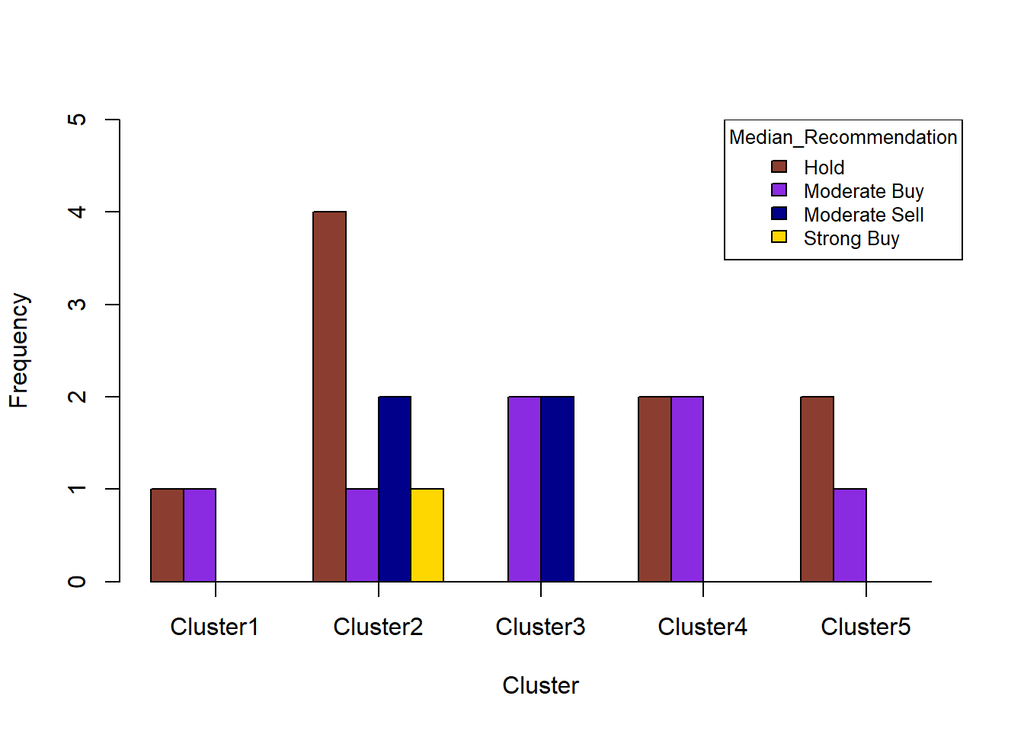

```r
Median_Recommendation<-ftable(Median_Recommendation, k5.cluster)
color.names = c("coral4","blueviolet","darkblue","gold") #select the colors for bar chart
barplot(Median_Recommendation,beside=T,ylim=c(0,5),xlab="Cluster",ylab="Frequency", names.arg = c("Cluster1", "Cluster2", "Cluster3", "Cluster4", "Cluster5"), col=color.names,axis.lty="solid")
legend("topright",legend = c("Hold", "Moderate Buy", "Moderate Sell", "Strong Buy"),cex =0.8,fill=color.names,title="Median_Recommendation")
```

### Bar chart of Location

```r
#[Section 3.2]
ftable(Location,k5.cluster) #create a pivot table
```

```
##             k5.cluster 1 2 3 4 5
## Location
## CANADA                 1 0 0 0 0
## FRANCE                 0 0 1 0 0
## GERMANY                0 0 0 0 1
## IRELAND                0 0 1 0 0
## SWITZERLAND            0 1 0 0 0
## UK                     0 2 0 1 0
## US                     1 5 2 3 2
```

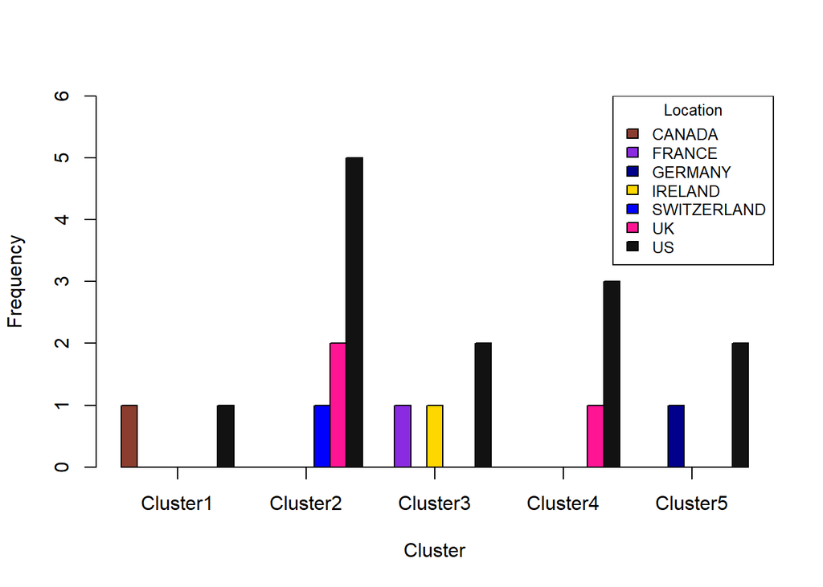

```r
Location<-ftable(Location, k5.cluster)
color.names = c("coral4","blueviolet","darkblue","gold", "blue", "deeppink", "grey7") #select the colors for bar chart
barplot(Location,beside=T,ylim=c(0,6),xlab="Cluster",ylab="Frequency", names.arg = c("Cluster1", "Cluster2", "Cluster3", "Cluster4", "Cluster5"), col=color.names,axis.lty="solid")
legend("topright",legend = c("CANADA", "FRANCE", "GERMANY", "IRELAND", "SWITZERLAND", "UK", "US"),cex =0.8,fill=color.names,title="Location")
```

### Bar chart of Exchange

```r
#[Section 3.3]
ftable(Exchange,k5.cluster) #create a pivot table
```

```
##          k5.cluster 1 2 3 4 5
## Exchange
## AMEX                0 0 0 0 1
## NASDAQ              0 0 0 0 1
## NYSE                2 8 4 4 1
```

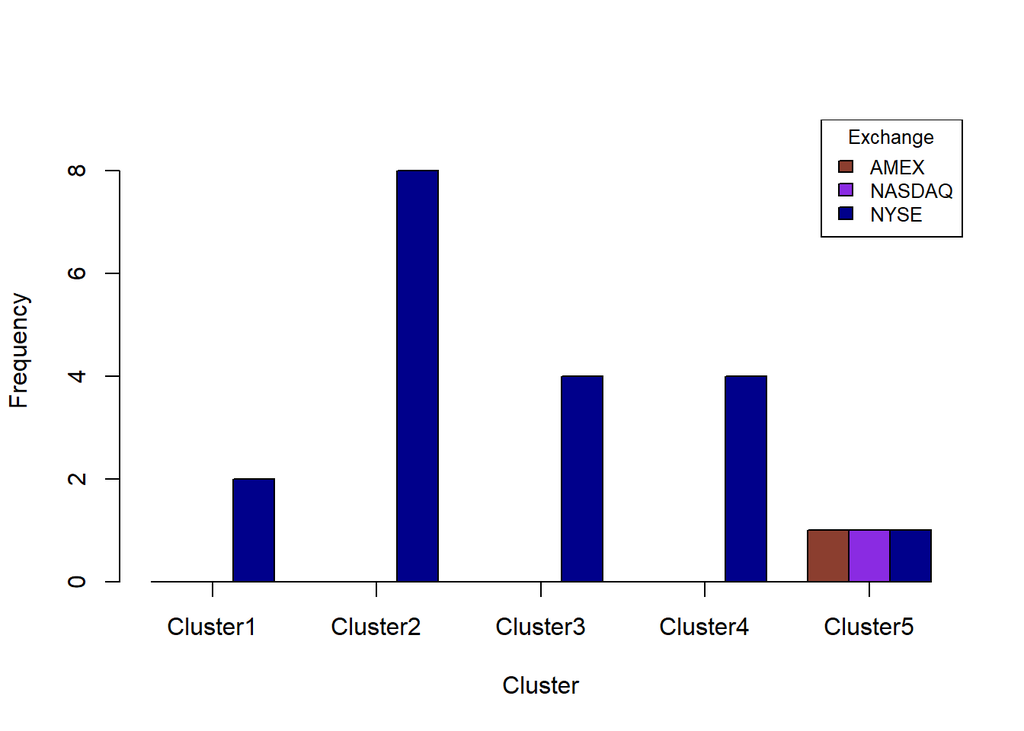

```r
Exchange<-ftable(Exchange, k5.cluster)
color.names = c("coral4","blueviolet","darkblue") #select the colors for bar chart
barplot(Exchange,beside=T,ylim=c(0,9),xlab="Cluster",ylab="Frequency", names.arg = c("Cluster1", "Cluster2", "Cluster3", "Cluster4", "Cluster5"), col=color.names,axis.lty="solid")
legend("topright",legend = c("AMEX", "NASDAQ", "NYSE"),cex =0.8,fill=color.names,title="Exchange")
```

## Clustering using the categorical variables

```r
#[Section 3.4]
#Compare the clusters generated based on the unused variable only (10 ~ 12) vs. clusters generated with used variables (1 ~ 9)
data.frame(colnames(mydata5_3))
```

| colnames.mydata5_3. |
| --- |
| Median_Recommendation |
| Location |
| Exchange |
| k5.cluster |
| N.Median_Rec |
| N.Location |
| N.Exchange |
| Cluster |

```r
mydata5_3 <- dummy_cols(mydata5_3, select_columns = 'Median_Recommendation') # Create the dummy value
mydata5_3 <- dummy_cols(mydata5_3, select_columns = 'Location') # Create the dummy value
mydata5_3 <- dummy_cols(mydata5_3, select_columns = 'Exchange') # Create the dummy value
View(mydata5_3)
data.frame(colnames(mydata5_3))
```

| colnames.mydata5_3. |
| --- |
| Median_Recommendation |
| Location |
| Exchange |
| k5.cluster |
| N.Median_Rec |
| N.Location |
| N.Exchange |
| Cluster |
| Median_Recommendation_Hold |
| Median_Recommendation_Moderate Buy |

[output cut: 12 more lines]

```r
Dummy<-mydata5_3[,c(9:22)] #subset containing only dummy values
View(Dummy)

#run the k-means algorithm using the unused variables to cluster the companies (k=5)
Dummy_scale<-scale(Dummy)
DummyKmeans<-kmeans(Dummy_scale, centers=5, nstart=25)
DummyKmeans
```

```
## K-means clustering with 5 clusters of sizes 7, 3, 3, 2, 6
##
## Cluster means:
##   Median_Recommendation_Hold Median_Recommendation_Moderate Buy
## 1                  1.1268723                         -0.6900656
## 2                 -0.8451543                         -0.6900656
## 3                 -0.1878121                         -0.6900656
## 4                  0.1408590                          0.3450328
## 5                 -0.8451543                          1.3801311
##   Median_Recommendation_Moderate Sell Median_Recommendation_Strong Buy
## 1                          -0.4733811                       -0.2182179
## 2                           2.0118695                       -0.2182179
## 3                           0.3550358                        1.3093073
## 4                          -0.4733811                       -0.2182179
## 5                          -0.4733811                       -0.2182179
##   Location_CANADA Location_FRANCE Location_GERMANY Location_IRELAND
## 1      -0.2182179      -0.2182179        0.4364358       -0.2182179
## 2      -0.2182179      -0.2182179       -0.2182179        1.3093073
## 3      -0.2182179      -0.2182179       -0.2182179       -0.2182179
## 4      -0.2182179      -0.2182179       -0.2182179       -0.2182179
## 5       0.5455447       0.5455447       -0.2182179       -0.2182179
##   Location_SWITZERLAND Location_UK Location_US Exchange_AMEX Exchange_NASDAQ
## 1            0.4364358  -0.3984095  0.19138975    -0.2182179      -0.2182179
## 2           -0.2182179  -0.3984095  0.09569488    -0.2182179      -0.2182179
## 3           -0.2182179   2.3904572 -1.24403338    -0.2182179      -0.2182179
## 4           -0.2182179  -0.3984095  0.76555900     2.0730700       2.0730700
## 5           -0.2182179  -0.3984095  0.09569488    -0.2182179      -0.2182179
##   Exchange_NYSE
## 1     0.3166238
## 2     0.3166238
## 3     0.3166238
## 4    -3.0079260
## 5     0.3166238
##
## Clustering vector:
##  [1] 5 5 3 3 5 1 2 4 2 1 3 4 5 5 1 1 5 1 1 2 1
##
## Within cluster sum of squares by cluster:
## [1] 41.76923 16.69231 20.71024 25.08730 40.38462
##  (between_SS / total_SS =  48.3 %)
##
## Available components:
##
## [1] "cluster"      "centers"      "totss"        "withinss"     "tot.withinss"
## [6] "betweenss"    "size"         "iter"         "ifault"
```

```r
#Cluster Information
Dummycluster<-data.frame(DummyKmeans$cluster)
View(Dummycluster)
```

## RandIndex

```r
#F-table (unused cluster vs used cluster)
clustercomp<-cbind(cluster5, Dummycluster) #Combining two cluster-sets, one with categorical variables (10~12) only, another with numerical variable (1~9) only
View(clustercomp)
print(clustercomp)
```

```
##      k5.cluster DummyKmeans.cluster
## ABT           2                   5
## AGN           1                   5
## AHM           2                   3
## AZN           2                   3
## AVE           3                   5
## BAY           5                   1
## BMY           2                   2
## CHTT          5                   4
## ELN           3                   2
## LLY           2                   1
## GSK           4                   3
## IVX           5                   4
## JNJ           4                   5
## MRX           3                   5
## MRK           4                   1
## NVS           2                   1
## PFE           4                   5
## PHA           1                   1
## SGP           2                   1
## WPI           3                   2
## WYE           2                   1
```

```r
attach(clustercomp)
comparison<-table(k5.cluster,DummyKmeans.cluster)
randIndex(comparison) # Measure of the similarity between two data clusterings. Similarity score between -1.0 and 1.0. 1.0 stands for perfect match.
```

```
##        ARI
## 0.05771089
```

# 4. Naming the clusters

**Provide an appropriate name for each cluster using any or all of the variables in the dataset.**

- Answer: The name of the cluster has been decided based on the best performance index the cluster achieved among clusters.  
  Cluster 1: PE_Ratio  
  Cluster 2: Vanilla (Cluster 2 doesn’t show any distinctive qualities/index among clusters)  
  Cluster 3: Rev_Growth  
  Cluster 4: Market_Cap  
  Cluster 5: Leverage

**Solution:** ## Plotting profile (centroid) of clusters

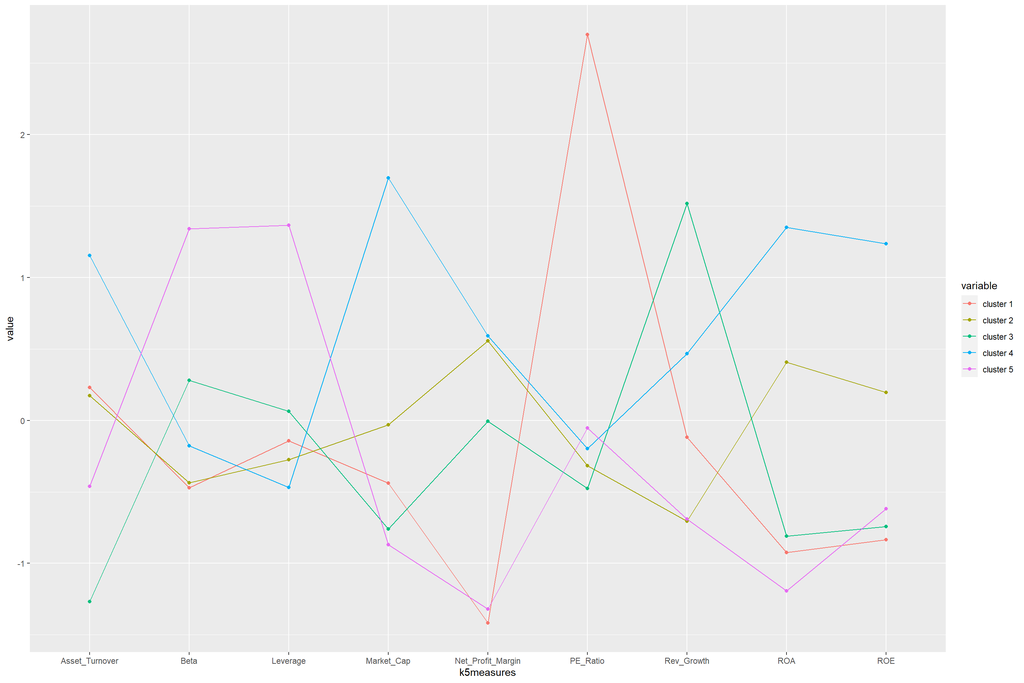

```r
##plotting profile plot based on the scaled value (k=5)
cluster5dimension<-data.frame(k5$centers)
cluster5dimensions<-as.data.frame(t(cluster5dimension))
cluster5dimensions$k5measures <- rownames(cluster5dimensions)
colnames(cluster5dimensions) <- c("cluster 1","cluster 2","cluster 3","cluster 4","cluster 5", "k5measures")
cluster5dimensions <- melt(cluster5dimensions, id.vars=c("k5measures"))
ggplot(cluster5dimensions, aes(x=k5measures, y=value, color=variable, group=variable)) + geom_line() + geom_point()
```